# Classification of Rice Varieties (Data Divas)

# Helper Functions

```python
# Importing
from sklearn.linear_model import LogisticRegression
from sklearn.discriminant_analysis import LinearDiscriminantAnalysis as LDA
from sklearn.discriminant_analysis import QuadraticDiscriminantAnalysis as QDA
import pandas as pd
import numpy as np
from sklearn.model_selection import cross_val_score
from sklearn.model_selection import KFold
from sklearn.base import BaseEstimator, TransformerMixin
from sklearn.pipeline import Pipeline
import matplotlib.pyplot as plt
import seaborn as sns
```

```python
# Removes from X the specified features
def rm_feature(X, omitted_features):
    X = X.drop(columns=omitted_features)
    return X

# Performs k-fold cross validation
def k_fold_cv(model, X, y, cv_size=20):
    k_fold_splitter = KFold(n_splits=cv_size, random_state=1,
                                     shuffle=True)
    scores = cross_val_score(model,
        X,
        y,
        scoring = 'accuracy',
        cv = k_fold_splitter,
        n_jobs = -1)
    return np.mean(scores)

# Create a submission file, according to the specified model, training and test data
def save_submission(model, X_train, X_test, y_train, text):
    model.fit(X_train, y_train)
    y_pred = model.predict(X_test)
    y_pred = pd.DataFrame(y_pred)
    y_pred.to_csv(text, index=False, header=False, sep='\t')


# Compute correlation matrix
def corr_matrix(data):
    corr = data.corr()
    corr.style.background_gradient(cmap='coolwarm')
    corr.style.background_gradient(cmap='coolwarm').format(precision=2)
    plt.figure(figsize=(8,3))
    sns.heatmap(corr, cmap="Greens",annot=True)
    plt.show()
    return corr


# Class which returns the top correlated features with 'Class'. The object
# inherits from 'BaseEstimator' and 'TransformerMixin', so that we can plug it in
# a scikit-learn pipeline and perform feature selection avoiding data leakage.
class GetTopCorrFeatures(BaseEstimator, TransformerMixin):
    def __init__(self, top_n=5):
      self.top_n = top_n

    def fit(self, X, y = None):
        X = pd.DataFrame(X)
        corr = np.array(X.apply(lambda x: x.corr(y)))
        corr_indexes = np.argsort(abs(corr))[::-1]
        self.top_corr_indexes = corr_indexes[0:self.top_n]
        return self

    def transform(self, X):
        X = np.array(X)
        X = X[:,self.top_corr_indexes]
        return X
```

# Importing

```python
train = pd.read_csv("rice_train.csv")
test = pd.read_csv("rice_test.csv")
```

```python
X_train = rm_feature(train, ['Class'])
y_train = train['Class']
X_test = test
```

# EDA

```python
train.info()
```

```
<class 'pandas.core.frame.DataFrame'>
RangeIndex: 2810 entries, 0 to 2809
Data columns (total 8 columns):
 #   Column             Non-Null Count  Dtype
---  ------             --------------  -----
 0   Area               2810 non-null   int64
 1   Perimeter          2810 non-null   float64
 2   Major_Axis_Length  2810 non-null   float64
 3   Minor_Axis_Length  2810 non-null   float64
 4   Eccentricity       2810 non-null   float64
 5   Convex_Area        2810 non-null   int64
 6   Extent             2810 non-null   float64
 7   Class              2810 non-null   int64
dtypes: float64(5), int64(3)
memory usage: 175.8 KB
```

We notice that there are no categorical variables nor null-values in the features.

```python
print(train.head(10))
```

```
    Area   Perimeter  Major_Axis_Length  Minor_Axis_Length  Eccentricity  \
0  15231  525.578979         229.749878          85.093788      0.928882
1  14656  494.311005         206.020065          91.730972      0.895405
2  14634  501.122009         214.106781          87.768288      0.912118
3  13176  458.342987         193.337387          87.448395      0.891861
4  14688  507.166992         211.743378          89.312454      0.906691
5  13479  477.015991         200.053055          86.650291      0.901328
6  15757  509.281006         207.296677          98.336136      0.880323
7  16405  526.570007         221.612518          95.436707      0.902521
8  14534  483.640991         196.650818          95.050682      0.875429
9  13485  471.570007         198.272644          87.727287      0.896789

   Convex_Area    Extent  Class
0        15617  0.572896      1
1        15072  0.615436      1
2        14954  0.693259      1
3        13368  0.640669      1
4        15262  0.646024      1
5        13786  0.657897      1
6        16150  0.589708      1
7        16837  0.658888      1
8        14932  0.649651      1
9        13734  0.572320      1
```

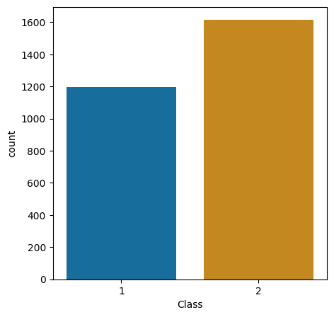

```python
plt.figure(figsize=(5, 5))
sns.countplot(x='Class', data=train, hue='Class', palette='colorblind', dodge=False, legend=False)
plt.show()
```

We notice that the classes are balanced and neither of the two is present in much greater quantity than the other.

## Outlier detection

To identify outliers using the Interquartile Range (IQR) method, one common approach is to employ the 1.5 * IQR rule. This rule defines outliers as values that deviate significantly from the central tendency of the data. Mathematically, outliers are determined based on the lower and upper boundaries set by the first quartile (Q1) and the third quartile (Q3), respectively, augmented by a factor of 1.5 times the IQR.

The Interquartile Range (IQR) is calculated as:

*IQR = Q3 - Q1*

where *Q1* represents the first quartile and *Q3* represents the third quartile of the data.

Using the 1.5 $\times$ IQR rule, outliers are identified as follows:

1. Lower Bound: Q1 - 1.5 $\times$ IQR
2. Upper Bound: Q3 + 1.5 $\times$ IQR

Any data points falling below the lower bound or above the upper bound are considered outliers, and may be subjected to further investigation since it might eliminate legitimate values that are not errors or anomalies but rather interesting or meaningful variations.

```python
#Calculate IQR and return outliers index vectors
def iqr_calculation(column):
    Q1 = np.percentile(column, 25, method='linear')
    Q3 = np.percentile(column, 75, method='linear')
    IQR = Q3 - Q1
    upper = np.where(column >= (Q3 + 1.5 * IQR))
    lower = np.where(column <= (Q1 - 1.5 * IQR))
    return upper, lower


#Remove outliers
def remove_outliers(data,upper,lower):
    data = data.drop(upper[0])
    data = data.drop(lower[0])
    data = data.reset_index()
    data = data.drop(columns=['index'])
    return data

#Effectively removing them from the dataset
def remove_outliers_data(data):
    for i in range(len(data.columns)):
        upper, lower = iqr_calculation(data[data.columns[i]])
        data = remove_outliers(data,upper,lower)
    return data
```

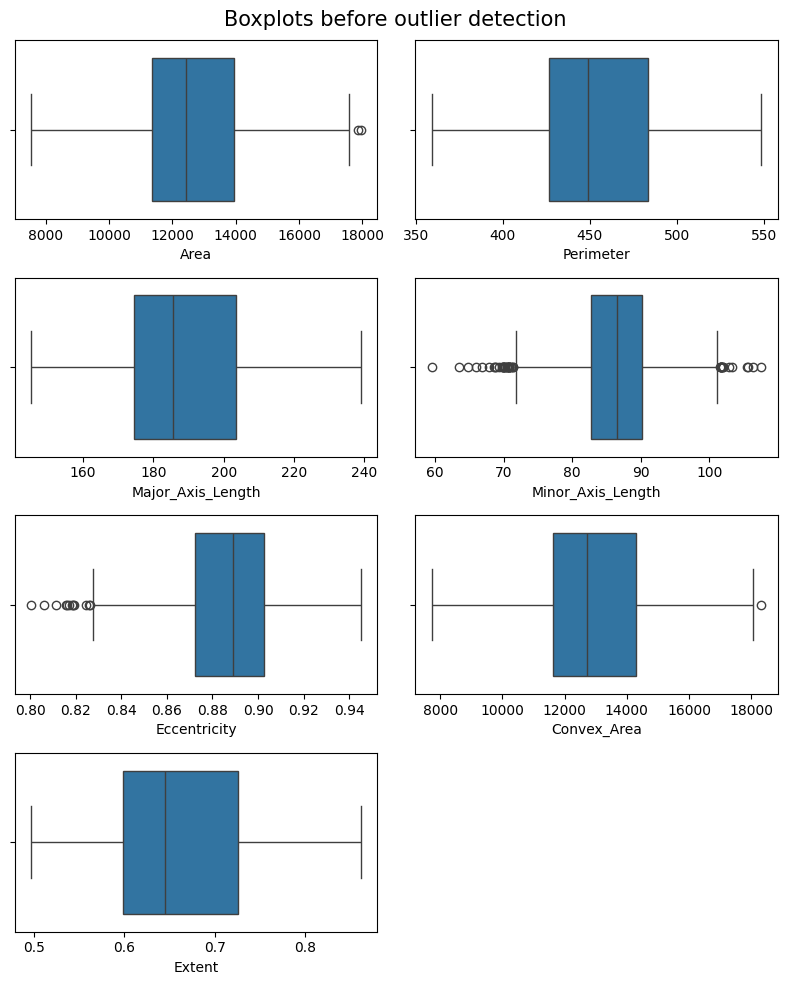

```python
fig, axes = plt.subplots(4, 2, figsize=(8, 10))
column_names = list(train.columns)

for i in range(3):
    for j in range(2):
        k = i * 2 + j
        if k < len(train.columns):
            sns.boxplot(ax=axes[i, j], data=train, x=train.columns[k], dodge=False, legend=False)

k = 6
sns.boxplot(ax=axes[-1, 0], data=train, x=train.columns[k], dodge=False, legend=False)

fig.suptitle('Boxplots before outlier detection', fontsize=15)

axes[-1, -1].axis('off')

plt.tight_layout()
plt.show()
```

We notice how "Eccentricity" and "Minor_Axis_Length" have some noticeble outliers.

```python
train_no_outliers = train.copy()

train_no_outliers = remove_outliers_data(train_no_outliers)

print(len(train)-len(train_no_outliers),"observations got removed from the original dataset.")
```

```
57 observations got removed from the original dataset.
```

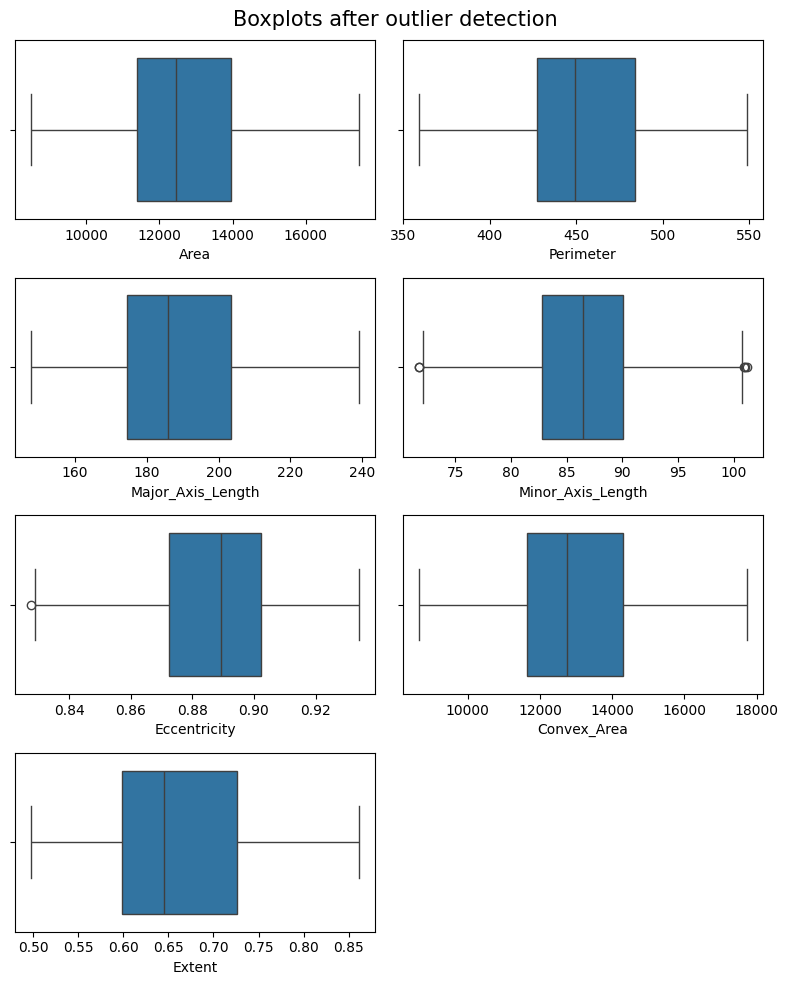

```python
fig, axes = plt.subplots(4, 2, figsize=(8, 10))
train_no_outliers

for i in range(3):
    for j in range(2):
        k = i * 2 + j
        if k < len(train_no_outliers.columns):
            sns.boxplot(ax=axes[i, j], data=train_no_outliers, x=train_no_outliers.columns[k], dodge=False, legend=False)

k = 6
sns.boxplot(ax=axes[-1, 0], data=train_no_outliers, x=train_no_outliers.columns[k], dodge=False, legend=False)

fig.suptitle('Boxplots after outlier detection', fontsize=15)

axes[-1, -1].axis('off')

plt.tight_layout()
plt.show()
```

## Pairplot

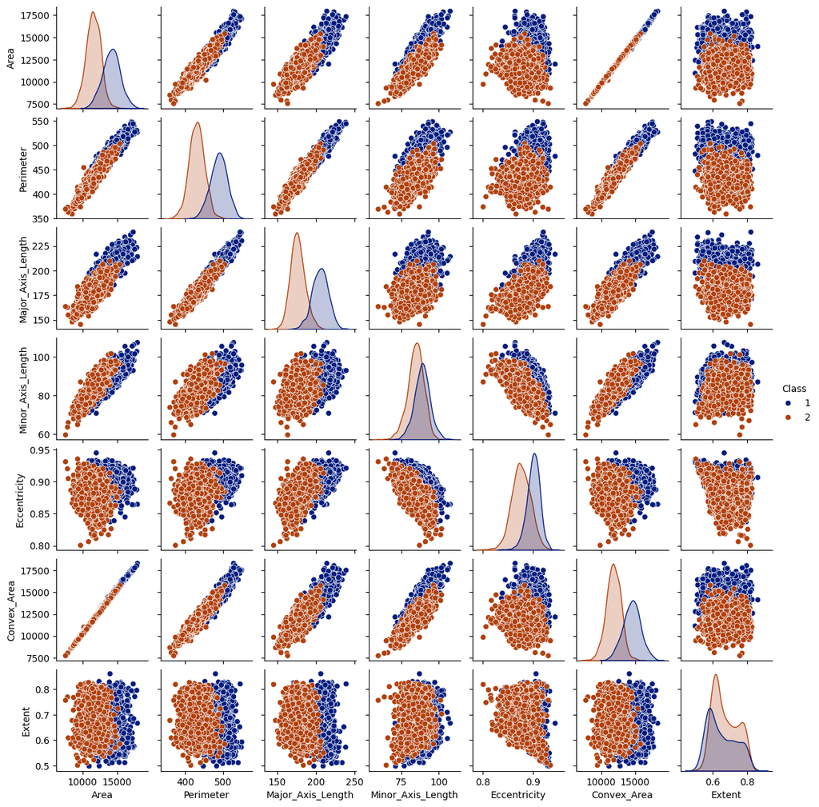

```python
fig = sns.pairplot(train, diag_kind='kde', hue='Class', palette='dark', height=2)
fig.fig.set_size_inches(12,12)
plt.show()
```

We see from the plots that some features are highly correlated. For example, we see that "Convex_Area" and "Area" are almost the same, which is not really surprising, because Convex area and Area are very similar quantities.

From the plots on the diagonal we can see distribution of samples of each class according to corresponding feature. From this we can guess that some of the features may be better for prediction than others. For example, in the diagonal plot of 'Area', 'Perimeter' and 'Major_Axis_length', the distributions don't overlap like in "Extent" or 'Minor_Axis_Length', so we can expect the first three feature to perform better in a prediction task than the others.

## Correlation Matrix

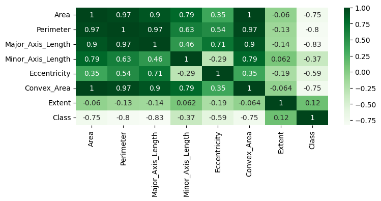

```python
corr = corr_matrix(train)
```

```python
threshold = 0.7

highly_correlated_pairs = []
for i in range(len(corr.columns)):
    for j in range(i):
        if abs(corr.iloc[i, j]) > threshold:
            pair = (corr.columns[i], corr.columns[j])
            highly_correlated_pairs.append((corr.iloc[i,j],pair))
highly_correlated_pairs.sort()
print("Highly correlated features with a correlation coefficient above", threshold, ":")
for pair,corr in highly_correlated_pairs:
    print(pair,'',corr)
```

```
Highly correlated features with a correlation coefficient above 0.7 :
-0.8271014811430777  ('Class', 'Major_Axis_Length')
-0.8044753282446043  ('Class', 'Perimeter')
-0.7501612963508957  ('Class', 'Convex_Area')
-0.746484263001029  ('Class', 'Area')
0.7062566279076042  ('Eccentricity', 'Major_Axis_Length')
0.7897548024045322  ('Convex_Area', 'Minor_Axis_Length')
0.7902270102078721  ('Minor_Axis_Length', 'Area')
0.9035632458278442  ('Major_Axis_Length', 'Area')
0.9039091224887812  ('Convex_Area', 'Major_Axis_Length')
0.9670401149898262  ('Perimeter', 'Area')
0.9704678759194757  ('Convex_Area', 'Perimeter')
0.9716318275104919  ('Major_Axis_Length', 'Perimeter')
0.9989527156219145  ('Convex_Area', 'Area')
```

Looking at the correlation matrix, we can see that, ('Convex_Area', 'Area'), ('Major_Axis_Length', 'Perimeter'), ('Convex_Area', 'Perimeter'), and ('Perimeter', 'Area'), form a group of highly correlated features, with correlation value over 0.9. Therefore, we can always keep few of the features from this group: ['Major_Axis_Length', 'Perimeter', 'Convex_Area', 'Area']

We can also notice that there are 4 features (['Major_Axis_Length', 'Perimeter', 'Convex_Area', 'Area']) which are highly correlated with 'Class'.

## Box plots

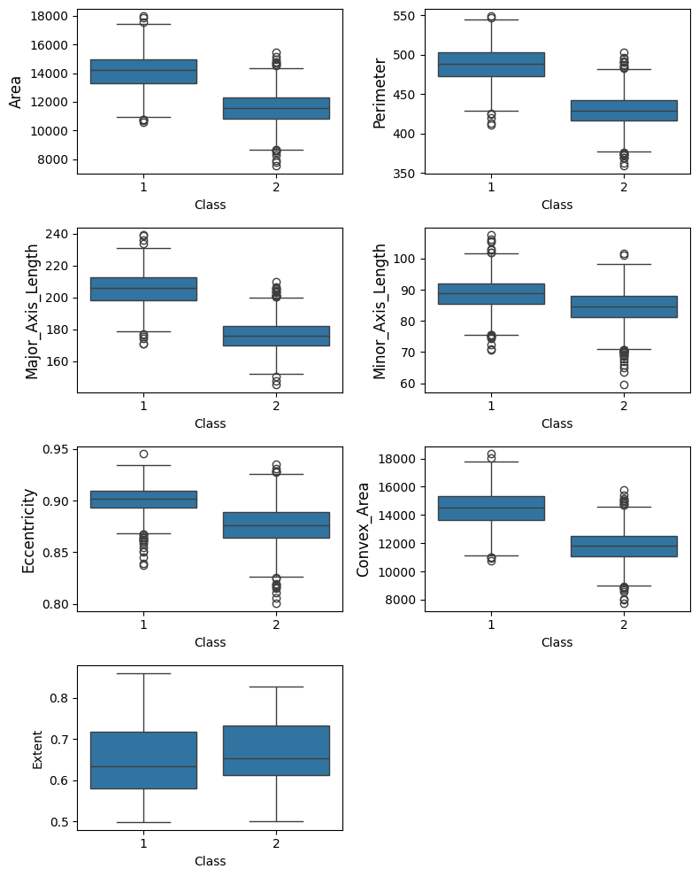

```python
fig, axes = plt.subplots(4, 2, figsize=(8, 10))

for i in range(3):
    for j in range(2):
        k = i * 2 + j
        if k < len(train.columns):
            sns.boxplot(ax=axes[i, j], data=train, x='Class', y=train.columns[k])
            axes[i, j].set_ylabel(train.columns[k], fontsize=12)

k = 6
sns.boxplot(ax=axes[-1, 0], data=train, x='Class',  y=train.columns[k], dodge=False, legend=False)

axes[-1, -1].axis('off')

plt.tight_layout()
plt.show()
```

We can see that higher values of 'Convex_Area', 'Major_Axis_Length' , 'Area' and 'Perimeter' are related to observations being classified as 1. On the other hand, Extent doesn't give many informations like others, since we can't really see a difference between the two predicted classes.

# Classification

For each classifier, we try to perform k-fold cross validation in 3 different experimental settings:

- **Without performing feature selection**
- **Keeping only the most prominent features.** In particular, from the analysis conducted so far, we know that the most correlated features with 'Class' are ['Major_Axis_Length', 'Perimeter', 'Convex_Area', 'Area'], while 'Extent' seems to be the worst predictor. However, we also know that ('Convex_Area', 'Area') and ('Major_Axis_Length', 'Perimeter') are highly correlated, so we think it's better to substitute one predictor from each pair with another feature, less correlated with the other one. In other words, we want to find a subset of features which maximizes the correlation with 'Class', while minimizing the correlation between pair of features. The resulting subset is the following: ['Major_Axis_Length', 'Minor_Axis_Length', 'Eccentricity', 'Convex_Area'].
- **Keeping only the top *n* correlated features with 'Class'**. This selection is done automatically using the GetTopCorrFeatures Object defined above, which avoids data leakage. For this homework, we set *n = 5*, since we can see that 'Minor_Axis_Length' and 'Extent' are poorly correlated with 'Class'.

Since the classes of the training examples seem to be balanced, we assume that the best performing models are the ones with the highest test accuracy, estimated using k-fold cross validation.

```python
feature_to_keep = ['Major_Axis_Length','Minor_Axis_Length','Eccentricity', 'Convex_Area']
```

## LDA

In this chunk, we perform Linear Discriminant Analysis according to the three experimental settings mentioned before.

```python
# Try LDA on the whole dataset, without any feature selection
lda = LDA()
print('Perform LDA on the whole dataset, without any feature selection:')
print(f"LDA Estimated test error: {k_fold_cv(lda, X_train, y_train)}")
save_submission(lda, X_train, X_test, y_train, "lda_plain.txt")
```

```
Perform LDA on the whole dataset, without any feature selection:
LDA Estimated test error: 0.9327912867274566
```

```python
# LDA selecting only the most prominent features
X_train_fs = X_train[feature_to_keep]
X_test_fs = X_test[feature_to_keep]
print('Perform LDA selecting only the most prominent features:')
print(f"LDA Estimated test error: {k_fold_cv(lda, X_train_fs, y_train)}")
```

```
Perform LDA selecting only the most prominent features:
LDA Estimated test error: 0.931724924012158
```

```python
# Perform LDA selecting the top correlated features with 'Class'
pipe = Pipeline([('fs',GetTopCorrFeatures(5)), ('model', LDA())])
print('Perform LDA selecting the top correlated features with Class:')
print(f"Estimated test error: {k_fold_cv(pipe, X_train, y_train)}")
```

```
Perform LDA selecting the top correlated features with Class:
Estimated test error: 0.9331408308004052
```

LDA seems to perform well. This can be due to the fact that there are few training observations, and so reducing variance is crucial. Therefore, using a less flexible classifier as LDA can lead to better performance than using a more complex model.

We can also notice that using only the 5 most correlated features with 'Class' to fit the model does not dramatically improve the perforance.

## QDA

We now run the same experiments as before, using QDA classifier.

```python
# Perform QDA on the whole dataset, without any feature selection
qda = QDA()
print('Perform QDA on the whole dataset, without any feature selection:')
print(f"Estimated test error: {k_fold_cv(qda, X_train, y_train)}")
```

```
Perform QDA on the whole dataset, without any feature selection:
Estimated test error: 0.9295668693009118
```

```python
# Perform QDA selecting only the most prominent features
X_train_fs = X_train[feature_to_keep]
X_test_fs = X_test[feature_to_keep]

print('Perform QDA selecting only the most prominent features:')
print(f"Estimated test error: {k_fold_cv(qda, X_train_fs, y_train)}")
```

```
Perform QDA selecting only the most prominent features:
Estimated test error: 0.9242249240121578
```

```python
# Perform QDA selecting the top 5 correlated features with 'Class'
pipe = Pipeline([('fs',GetTopCorrFeatures(5)), ('model', QDA())])
print('Perform QDA selecting the top 5 correlated features with Class:')
print(f"Estimated test error: {k_fold_cv(pipe, X_train, y_train)}")
save_submission(pipe, X_train, X_test, y_train, "qda_3.txt")
```

```
Perform QDA selecting the top 5 correlated features with Class:
Estimated test error: 0.9313551165146908
```

From the experiments we can see that the highest estimated test accuracy, according to the k-fold cross validation method, is obtained considering the 5 most correlated features with 'Class'.

We can also notice that QDA performs worse than LDA. This is probably because the dataset is small and/or the assumptions of QDA are not met.

## Logistic regression

We now perform logistic regression

```python
# Try Logistic regression on the whole dataset, without any feature selection
lgr = LogisticRegression()
print('Perform Logistic regression on the whole dataset, without any feature selection:')
print(f"Estimated test error: {k_fold_cv(lgr, X_train, y_train)}")
save_submission(lgr, X_train, X_test, y_train, "lgr_1.txt")
```

```
Perform Logistic regression on the whole dataset, without any feature selection:
Estimated test error: 0.9334903748733536
```

```python
# Logistic regression selecting only the most prominent features
X_train_fs = X_train[feature_to_keep]
X_test_fs = X_test[feature_to_keep]
print('Perform Logistic regression selecting only the most prominent features:')
print(f"Estimated test error: {k_fold_cv(lgr, X_train_fs, y_train)}")
```

```
Perform Logistic regression selecting only the most prominent features:
Estimated test error: 0.9331408308004052
```

```python
# Perform Logistic regression selecting the top correlated features with 'Class'
pipe = Pipeline([('fs',GetTopCorrFeatures(5)), ('model', LogisticRegression())])
print('Perform Logistic regression selecting the top correlated features with Class:')
print(f"Estimated test error: {k_fold_cv(pipe, X_train, y_train)}")
```

```
Perform Logistic regression selecting the top correlated features with Class:
Estimated test error: 0.9185587639311044
```

We can notice that Logistic regression and LDA perform similarly. However, keeping the 5 most correlated features with 'Class' leads, in this case, to worse performance

## KNN

In this chunk, we perform KNN classification according to the three experimental settings mentioned before. In particular, for each experiment, we try to fit several models with different values of the parameter K (from 1 to 100). Every model is evaluated using k-fold cross validation, and the final best performing model is printed. Note that we scale the data before applying the classifier, in order to improve KNN performance.

```python
from sklearn.neighbors import KNeighborsClassifier as KNN
from sklearn.preprocessing import StandardScaler
from sklearn.model_selection import GridSearchCV
```

```python
# Perform k-fold cross validation, trying different values of the parameter K
def run_knn(model, X, y, params, cv_size=10):
    k_fold_splitter = KFold(n_splits=cv_size, random_state=1,
                                     shuffle=True)
    grid = GridSearchCV(model,params,
                      scoring = 'accuracy',
                      n_jobs = -1,
                      cv = k_fold_splitter)
    grid.fit(X, y)

    best_params = grid.best_params_
    best_score = grid.best_score_
    return best_params, best_score
```

```python
# KNN without performing any feature selection
pipe = Pipeline([('scaler', StandardScaler()), ('model', KNN())])
params = {'model__n_neighbors': range(1,100)}
best_params, best_score = run_knn(pipe, X_train, y_train, params)
best_k = best_params['model__n_neighbors']
print('Perform KNN without performing any feature selection:\n')
print(f"Best K parameter: {best_k}\nBest Score: {best_score}")
```

```
Perform KNN without performing any feature selection:

Best K parameter: 35
Best Score: 0.9306049822064058
```

```python
# KNN selecting only the most prominent features
X_train_fs = X_train[feature_to_keep]
X_test_fs = X_test[feature_to_keep]

pipe = Pipeline([('scaler', StandardScaler()), ('model', KNN())])
params = {'model__n_neighbors': range(1,100)}
best_params, best_score = run_knn(pipe, X_train_fs, y_train, params)
best_k = best_params['model__n_neighbors']
print('Perform KNN selecting only the most prominent features:\n')
print(f"Best K parameter: {best_k}\nBest Score: {best_score}")
```

```
Perform KNN selecting only the most prominent features:

Best K parameter: 62
Best Score: 0.9313167259786477
```

```python
# KNN keeping only the top correlated features with 'Class'
pipe = Pipeline([('fs', GetTopCorrFeatures(5)),
                 ('scaler', StandardScaler()),
                 ('model', KNN())])
params = {'model__n_neighbors': range(1,100)}
best_params, best_score = run_knn(pipe, X_train, y_train, params)
best_k = best_params['model__n_neighbors']
print('Perform KNN keeping only the top correlated features with Class:\n')
print(f"Best K parameter: {best_k}\nBest Score: {best_score}")
```

```
Perform KNN keeping only the top correlated features with Class:

Best K parameter: 31
Best Score: 0.9316725978647685
```

We can notice that, in the case of KNN classification, performing feature selection improved performance. This is not surprising since we know that KNN has the *curse of dimensionality* problem, and its perfromance is likely to worsen as the data dimensionality increases.

### KNN with grid search

In the following cells of code, we fit a KNN classifier for each combination between the values of K and the number of most correlated features with 'Class' to keep. Then, we print the best result.

```python
pipe = Pipeline([('fs', GetTopCorrFeatures()),
                 ('scaler', StandardScaler()),
                 ('model', KNN())])
params = {'model__n_neighbors': range(5,100),
          'fs__top_n': range(1, 8),
          'model__weights' : ['uniform', 'distance']
          }
best_params, best_score = run_knn(pipe, X_train, y_train, params, 20)
best_k = best_params['model__n_neighbors']
best_top_n = best_params['fs__top_n']
print(f"Best K parameter: {best_k}\nBest top corr. features to keep: {best_top_n}\nBest Score: {best_score}")
print(f"Weights: {best_params['model__weights']}")
```

```
Best K parameter: 28
Best top corr. features to keep: 4
Best Score: 0.9324392097264438
Weights: distance
```

```python
pipe = Pipeline([('fs', GetTopCorrFeatures(best_top_n)),
                 ('scaler', StandardScaler()),
                 ('model', KNN(n_neighbors = best_k, weights='distance'))])

save_submission(pipe, X_train, X_test, y_train, "knn_grid_2.txt")
```

We can notice that, using this grid search approach, the KNN performance is comparable to the one of LDA and Logistic regression.

This approach can be implemented also for the others classifiers. However, we decided to keep things simple and avoid this kind of analysis, since it would increase too much the code complexity.

### KNN with forward feature selection

The last thing we want to try is forward stepwise feature selection with KNN, trying different values for K.

```python
from mlxtend.feature_selection import SequentialFeatureSelector as SFS
```

```python
def stepwise_feature_selection(X, y, estimator, forward,
                                n_features_to_select = 10, cv_size=10):

    k_fold_splitter = KFold(n_splits=cv_size, random_state=1,
                                     shuffle=True)
    sfs = SFS(
        estimator,
        k_features = n_features_to_select,
        forward=forward,
        floating=False,
        scoring = 'accuracy',
        cv=k_fold_splitter,
        n_jobs=-1
    )
    sfs.fit(X, y)
    return sfs.k_feature_idx_, sfs.k_score_
```

```python
res = []
for k in range(5, 100):
    pipe = Pipeline([('scaler', StandardScaler()),
                 ('model', KNN(n_neighbors = k, weights='distance'))])
    best_subset, best_score = stepwise_feature_selection(X_train, y_train, pipe,
                                                         True, 'best')

    res.append((k, best_subset, best_score))
```

```python
print('Perform KNN with stepwise forward feature selection')
best_k, best_sub, best_score = max(res, key = lambda x: x[2])
best_sub = list(best_sub)
print(f"Best K parameter: {best_k}")
print(f"Best subset of features: {list(X_train.columns[best_sub])}")
print(f"Best score: {best_score}")
```

```
Perform KNN with stepwise forward feature selection
Best K parameter: 35
Best subset of features: ['Area', 'Perimeter', 'Major_Axis_Length', 'Eccentricity', 'Convex_Area', 'Extent']
Best score: 0.9338078291814946
```

```python
X_train_knn = X_train[X_train.columns[best_sub]]
X_test_knn = X_test[X_test.columns[best_sub]]

pipe = Pipeline([('scaler', StandardScaler()),
                 ('model', KNN(n_neighbors = best_k, weights='distance'))])

save_submission(pipe, X_train_knn, X_test_knn, y_train, "knn_frw.txt")
```

Since forward feature selection is a very powerful technique, the resulting model performs slightly better than both LDA and Logistic regression.

It is surprising that the selected subset of features contains both 'Convex_Area' and 'Area', which have a correlation value of 1, and 'Extent', which is the least correlated predictor with 'Class'. Actually, we are not completely aware of the reasons behind the choice of this subset.

# Future Analysis

As additional analysis we could perform:

- Grid search trying different combination of models' hyperparameters
- Fit models on dataset without outliers
- Plot ROC curve

However, these kind of analysis are beyond the scope of this homework.

# Conclusions

According to our experiments, the best models seem to be Logistic regression and LDA. However, if we perform stepwise forward feature selection on KNN, trying different values of K, the resulting model is the best one.

This is also confirmed by submitting models' predictions on https://www.datachallenge.it/competitions/57#submissions, where our best KNN model gets a score of 0,94000.